# CMSC320 Final Tutorial

# Predicting the daily temperature

Group member: Zihan Ma, Mo Zhou, YuMing Huang

## The Question:

Since the weather is a chaotic system, it is really hard to predict the forecast future weather data by using equations. Therefore, we want to understand is it possible to predict daily temperature based on past temperature data using the machine learning technique. We try to use different methods to see which way predicts the better result and whether we could find a model to predict daily temperature for every day in a year.

```python
from azureml.opendatasets import NoaaIsdWeather
from datetime import datetime
from dateutil.relativedelta import relativedelta
import pandas as pd
import torch
import numpy as np
import matplotlib.pyplot as plt
import warnings
warnings.filterwarnings('ignore')
```

# Part 1 Data collection/curation

We use the data from Microsoft open database "NOAA Integrated Surface Data" (https://azure.microsoft.com/en-us/services/open-datasets/catalog/noaa-integrated-surface-data/). This database contains worldwide surface weather observations from over 35,000 stations, though the best spatial coverage is evident in North America, Europe, Australia, and parts of Asia. We use the method provided by Microsoft Azure to collect the data from their databases. Their method will return the temperature data in many locations, and we decide to focus on the temperature data in the DC area (Latitude: 38.8951 Longitude: -77.0364).

However, during the data collection, we found this step needs a lot of time and memory to collect data for several years since their function returns a lot of information and some of which we do not need. Therefore, we do the data collection for each year separately, and we only collect the data ('datetime','latitude','longitude','temperature') that we are looking for to save memory space. Then, we store them in out20XX.csv file, so that we could use them much easier and quicker in the future part.

```python
# Below is a sample about how we read one day data from the NOAA Integrated Surface Data bases.

# First we need to set start date and end date
end_date =  datetime(2016, 1, 2)
start_date = datetime(2016, 1, 1)

# Get historical weather data in the 2020 year.
isd = NoaaIsdWeather(start_date, end_date,['datetime','latitude','longitude','temperature'])

# Read into Pandas data frame.
isd_df = isd.to_pandas_dataframe()

# Select the temperature that is in DC area.
isd_df = isd_df.loc[(isd_df['latitude'] >= 38) & (isd_df['latitude'] <= 39) & (isd_df['longitude'] >= -78) & (isd_df['longitude'] <= -77)]
isd_df = isd_df.sort_values(by='datetime')
isd_df = isd_df[['datetime','latitude','longitude','temperature']]

# Store the data into csv file
isd_df.to_csv('sample.csv')
```

[output not shown]

```python
isd_df
```

|  | datetime | latitude | longitude | temperature |
| --- | --- | --- | --- | --- |
| 1316339 | 2016-01-01 00:00:00 | 38.850 | -77.033 | 10.0 |
| 499506 | 2016-01-01 00:00:00 | 38.983 | -77.483 | 8.9 |
| 1100918 | 2016-01-01 00:15:00 | 38.010 | -77.970 | 10.0 |
| 91833 | 2016-01-01 00:15:00 | 38.267 | -77.449 | 10.7 |
| 1096394 | 2016-01-01 00:15:00 | 38.527 | -77.859 | 9.1 |
| ... | ... | ... | ... | ... |
| 261976 | 2016-01-01 23:56:00 | 38.504 | -77.305 | 5.6 |
| 760213 | 2016-01-01 23:58:00 | 38.717 | -77.183 | 3.2 |
| 1257060 | 2016-01-02 00:00:00 | 38.941 | -77.464 | NaN |
| 170950 | 2016-01-02 00:00:00 | 38.850 | -77.033 | 4.4 |
| 910488 | 2016-01-02 00:00:00 | 38.983 | -77.483 | 2.8 |

519 rows × 4 columns

```python
# Then we repeat the similar process to gather the data from 2017 to 2021.
end_date =  datetime(2017, 12, 31)
start_date = datetime(2017, 1, 1)
isd = NoaaIsdWeather(start_date, end_date,['datetime','latitude','longitude','temperature'])
isd_df = isd.to_pandas_dataframe()
isd_df = isd_df.loc[(isd_df['latitude'] >= 38) & (isd_df['latitude'] <= 39) & (isd_df['longitude'] >= -78) & (isd_df['longitude'] <= -77)]
isd_df = isd_df.sort_values(by='datetime')
isd_df = isd_df[['datetime','latitude','longitude','temperature']]
isd_df
isd_df.to_csv('out2017_1.csv')
end_date =  datetime(2018, 12, 31)
start_date = datetime(2018, 1, 1)
isd = NoaaIsdWeather(start_date, end_date,['datetime','latitude','longitude','temperature'])
isd_df = isd.to_pandas_dataframe()
isd_df = isd_df.loc[(isd_df['latitude'] >= 38) & (isd_df['latitude'] <= 39) & (isd_df['longitude'] >= -78) & (isd_df['longitude'] <= -77)]
isd_df = isd_df.sort_values(by='datetime')
isd_df = isd_df[['datetime','latitude','longitude','temperature']]
isd_df
isd_df.to_csv('out2018_1.csv')
end_date =  datetime(2019, 12, 31)
start_date = datetime(2019, 1, 1)
isd = NoaaIsdWeather(start_date, end_date,['datetime','latitude','longitude','temperature'])
isd_df = isd.to_pandas_dataframe()
isd_df = isd_df.loc[(isd_df['latitude'] >= 38) & (isd_df['latitude'] <= 39) & (isd_df['longitude'] >= -78) & (isd_df['longitude'] <= -77)]
isd_df = isd_df.sort_values(by='datetime')
isd_df = isd_df[['datetime','latitude','longitude','temperature']]
isd_df
isd_df.to_csv('out2019_1.csv')
end_date =  datetime(2020, 12, 31)
start_date = datetime(2020, 1, 1)
isd = NoaaIsdWeather(start_date, end_date,['datetime','latitude','longitude','temperature'])
isd_df = isd.to_pandas_dataframe()
isd_df = isd_df.loc[(isd_df['latitude'] >= 38) & (isd_df['latitude'] <= 39) & (isd_df['longitude'] >= -78) & (isd_df['longitude'] <= -77)]
isd_df = isd_df.sort_values(by='datetime')
isd_df = isd_df[['datetime','latitude','longitude','temperature']]
isd_df
isd_df.to_csv('out2020_1.csv')
end_date =  datetime(2021, 5, 1)
start_date = datetime(2021, 1, 1)
isd = NoaaIsdWeather(start_date, end_date,['datetime','latitude','longitude','temperature'])
isd_df = isd.to_pandas_dataframe()
isd_df = isd_df.loc[(isd_df['latitude'] >= 38) & (isd_df['latitude'] <= 39) & (isd_df['longitude'] >= -78) & (isd_df['longitude'] <= -77)]
isd_df = isd_df.sort_values(by='datetime')
isd_df = isd_df[['datetime','latitude','longitude','temperature']]
isd_df.to_csv('out2021_1.csv')
```

# Part 2 Data management/representation

Now, we can read data from the CSV file to save time. To tidy our data, we first drop any row that contains missing values. Since we are focus on the daily temperature, we create a new column called "date" that represents only the date information of that row, hence, we can calculate the mean of several observations of temperature data in one day. We will also remove the information that we are not looking for in the future part, like 'latitude' and 'longitude', and only keep the date and temperature data.

```python
# Read data from csv file
isd_df = pd.read_csv('out2017_1.csv')

# Drop missing value
isd_df = isd_df.dropna()

# Create the date column based on datetime column
isd_df['date'] = isd_df.apply(lambda row: str(row.datetime)[0:10], axis=1)

# Remove unnecessary data
isd_df = isd_df[['date','temperature']]

# Calculate the mean temperature for each day
isd_df = isd_df.groupby('date').mean()
isd_df
```

| date | temperature |
| --- | --- |
| 2017-01-01 | 7.327972 |
| 2017-01-02 | 6.300692 |
| 2017-01-03 | 6.517524 |
| 2017-01-04 | 8.995238 |
| 2017-01-05 | 0.911695 |
| ... | ... |
| 2017-12-27 | -1.481212 |
| 2017-12-28 | -7.106721 |
| 2017-12-29 | -5.933537 |
| 2017-12-30 | -4.085432 |
| 2017-12-31 | -2.800000 |

365 rows × 1 columns

```
1. Date: The date of the row
2. Temperature: the average temperature of that date
```

The we need to update the csv file to make future process easier。

```python
# Update the file

isd_df.to_csv('out2017.csv')
```

```python
# Did same thing for the 2018 to 2021 year
isd_df = pd.read_csv('out2018_1.csv')
isd_df = isd_df.dropna()
isd_df['date'] = isd_df.apply(lambda row: str(row.datetime)[0:10], axis=1)
isd_df = isd_df[['date','temperature']]
isd_df = isd_df.groupby('date').mean()
isd_df.to_csv('out2018.csv')

isd_df = pd.read_csv('out2019_1.csv')
isd_df = isd_df.dropna()
isd_df['date'] = isd_df.apply(lambda row: str(row.datetime)[0:10], axis=1)
isd_df = isd_df[['date','temperature']]
isd_df = isd_df.groupby('date').mean()
isd_df.to_csv('out2019.csv')

isd_df = pd.read_csv('out2020_1.csv')
isd_df = isd_df.dropna()
isd_df['date'] = isd_df.apply(lambda row: str(row.datetime)[0:10], axis=1)
isd_df = isd_df[['date','temperature']]
isd_df = isd_df.groupby('date').mean()
isd_df.to_csv('out2020.csv')

isd_df = pd.read_csv('out2021_1.csv')
isd_df = isd_df.dropna()
isd_df['date'] = isd_df.apply(lambda row: str(row.datetime)[0:10], axis=1)
isd_df = isd_df[['date','temperature']]
isd_df = isd_df.groupby('date').mean()
isd_df.to_csv('out2021.csv')
```

# Part 3: Data Analysis & Visualization

Now, we can easily start exploring data using saved files instead of spending a huge amount of time importing from azureml.opendatasets. Before we start to analyze, we still need to combine four years' temperature data into two DataFrames. One will contain average temperature each day and another one will have an average temperature each month. We use a groupby function to sort the data and take the mean.Resulting dataframes are shown below.

```python
Average_tempertuare_per_month = None
Average_tempertuare_per_day = None

for i in range(2017,2021):
    #read each year's data
    Year = pd.read_csv("out"+ str(i) +".csv")
    Month = Year.copy()
    Day = Year.copy()
    #Group by Month, take the mean
    Month['date'] = Month.apply(lambda row: str(row.date)[5:7], axis=1)
    Month = Month.rename(columns={"date":"month"})
    Month = Month.groupby('month').mean()

    #Group by Day, take the mean
    Day['date'] = Day.apply(lambda row: str(row.date)[5:10], axis=1)
    Day = Day.groupby('date').mean()

    # Put four year's temperature data into two dataframe: Each Month, Each Day
    if i == 2017:
        Average_tempertuare_per_month = Month.copy().rename(columns={"temperature": "temperature_2017", "date":"month"})
    else:
        Average_tempertuare_per_month["temperature_"+ str(i)] = Month["temperature"]

    if i == 2017:
        Average_tempertuare_per_day = Day.copy().rename(columns={"temperature": "temperature_2017"})
    else:
        Average_tempertuare_per_day["temperature_"+ str(i)] = Day["temperature"]

Average_tempertuare_per_month
```

| month | temperature_2017 | temperature_2018 | temperature_2019 | temperature_2020 |
| --- | --- | --- | --- | --- |
| 01 | 4.856666 | 0.745066 | 1.646986 | 4.740344 |
| 02 | 8.186317 | 6.663374 | 4.350292 | 5.797596 |
| 03 | 7.879036 | 4.994242 | 7.070025 | 10.948296 |
| 04 | 16.805265 | 11.799273 | 15.255233 | 12.049605 |
| 05 | 17.612875 | 21.196281 | 20.401757 | 16.744295 |
| 06 | 23.328552 | 22.829835 | 23.006440 | 23.328091 |
| 07 | 25.685452 | 24.723617 | 26.223509 | 27.066091 |
| 08 | 23.103541 | 24.910098 | 24.579848 | 24.648758 |
| 09 | 20.062609 | 22.400255 | 22.622308 | 19.586389 |
| 10 | 16.091589 | 15.130229 | 16.119504 | 14.890668 |
| 11 | 7.747990 | 6.623186 | 6.368640 | 10.936819 |
| 12 | 2.738894 | 4.129207 | 4.419583 | 4.131273 |

```python
Average_tempertuare_per_day
```

| date | temperature_2017 | temperature_2018 | temperature_2019 | temperature_2020 |
| --- | --- | --- | --- | --- |
| 01-01 | 7.327972 | -9.574132 | 13.037563 | 4.736576 |
| 01-02 | 6.300692 | -9.550000 | 6.097679 | 2.887814 |
| 01-03 | 6.517524 | -8.771891 | 7.402119 | 10.032107 |
| 01-04 | 8.995238 | -3.459494 | 3.810424 | 11.769565 |
| 01-05 | 0.911695 | -8.404303 | 8.343328 | 6.165049 |
| ... | ... | ... | ... | ... |
| 12-27 | -1.481212 | 1.780290 | 6.059762 | -1.426233 |
| 12-28 | -7.106721 | 8.153070 | 7.949648 | 4.102772 |
| 12-29 | -5.933537 | 9.109333 | 8.995678 | 4.035742 |
| 12-30 | -4.085432 | 4.302245 | 13.581795 | 0.497400 |
| 12-31 | -2.800000 | 4.450000 | 9.800000 | 5.833333 |

365 rows × 4 columns

## Part 3.1 Data Visualization

Let's first simply plot two dataframes using matplotlib.pyplot.

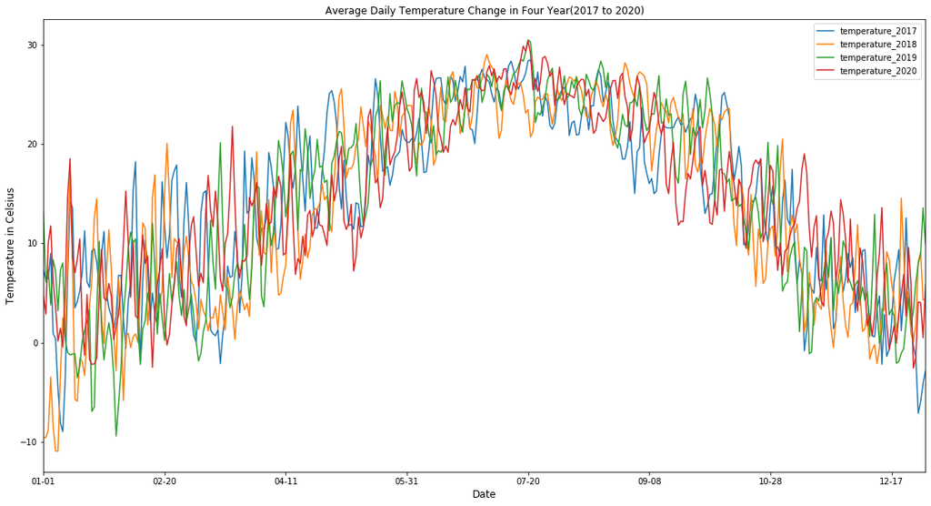

```python
#Plot for daily temperature
fig, ax = plt.subplots(figsize=(19, 10))
Average_tempertuare_per_day.plot(ax = ax)
plt.title("Average Daily Temperature Change in Four Year(2017 to 2020)")
plt.ylabel("Temperature in Celsius", size = 12)
plt.xlabel("Date", size = 12)
plt.show()
```

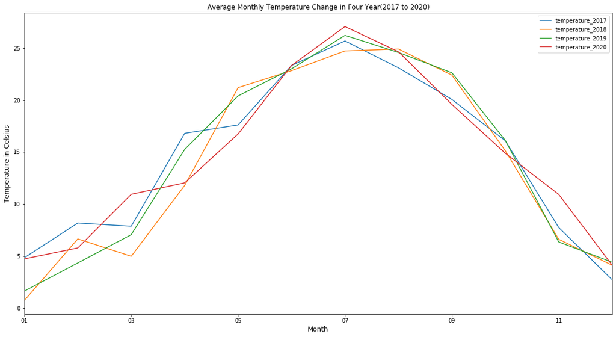

```python
#Plot for monthly temperature
fig, ax = plt.subplots(figsize=(19, 10))
Average_tempertuare_per_month.plot(ax = ax)
plt.title("Average Monthly Temperature Change in Four Year(2017 to 2020)")
plt.ylabel("Temperature in Celsius", size = 12)
plt.xlabel("Month", size = 12)
plt.show()
```

From the above two plots, we can see that even though the average temperature for each day or each month varies a lot between four years, there is a general trend of how temperature changes within a single year. It will increase until July or August, and start to decrease until the next year. We also want to see how temperatures are distributed within each month, so we decided to use the violin plot.

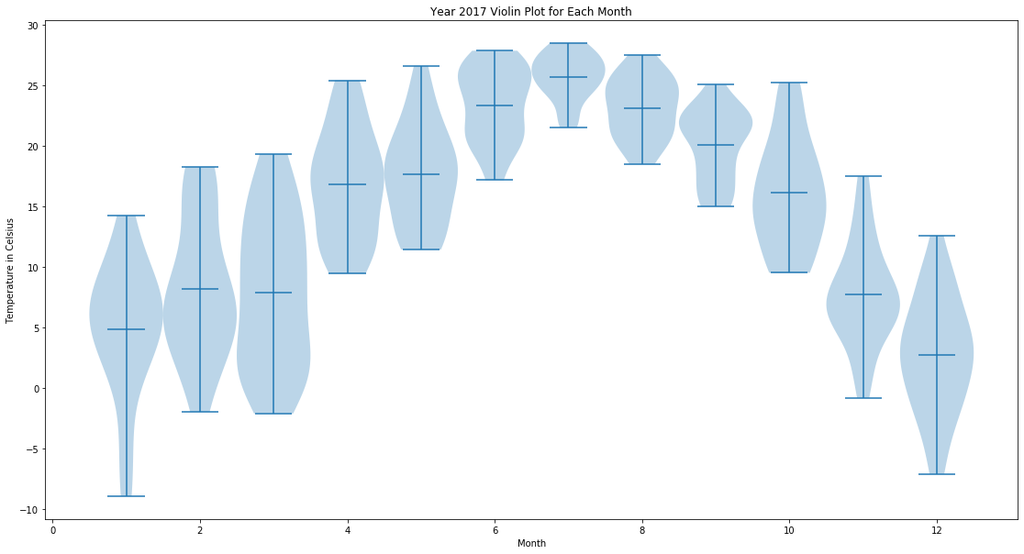

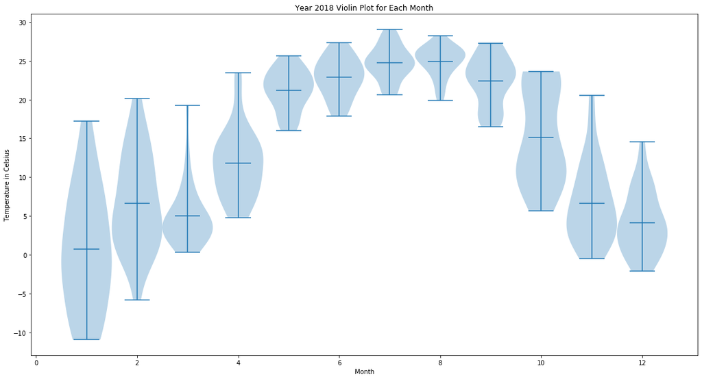

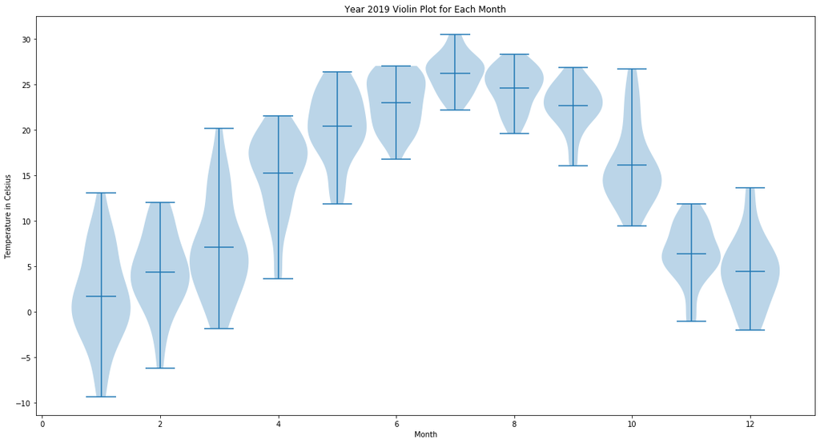

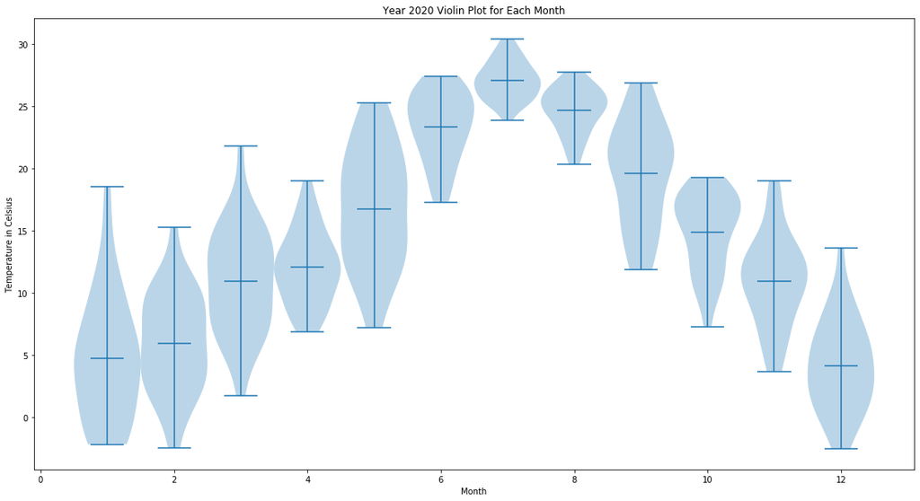

```python
#Process data for violin plot
Month_list = ["01", "02", "03", "04", "05", "06", "07", "08", "09", "10", "11", "12"]
dates = np.array(Average_tempertuare_per_day.index)
Month_list_num = [1,2,3,4,5,6,7,8,9,10,11,12]
for year in Average_tempertuare_per_day.columns:
    t_per_year = []
    for i in range(0, 12):
        #Put data point in the same month into one array
        t_per_month = []
        for x in range(0,365):
            if dates[x][0:2] == Month_list[i]:
                t_per_month.append(Average_tempertuare_per_day[year].iloc[x])
        t_per_year.append(t_per_month)

    #Violin plot
    fig, ax = plt.subplots(figsize=(19, 10))
    plt.violinplot(t_per_year,Month_list_num,widths=1,showmeans=True)
    plt.xlabel("Month")
    plt.ylabel("Temperature in Celsius")
    plt.title("Year " +year[12:] + " Violin Plot for Each Month")
    plt.show()
```

# Part 4: Hypothesis testing and machine learning

## Getting the actual data

```python
isd_df1 = pd.read_csv('out2020.csv')
isd_df2 = pd.read_csv('out2017.csv')
isd_df3 = pd.read_csv('out2018.csv')
isd_df4 = pd.read_csv('out2019.csv')
isd_df5 = pd.read_csv('out2021.csv')
```

## Find the model

We choose to use the temperature data from 2017 to find the model

```python
z = np.poly1d(np.polyfit(range(1,366),isd_df2['temperature'], 2))
z
```

```
poly1d([-7.29352439e-04,  2.74125249e-01, -3.10932747e+00])
```

Therefore, we found the model that

$temperature = -7.29352439e-04*x^2 + 2.74125249e-01*x - 3.10932747e+00$

## Comparing the result

After we found the model, we can use that model to see how well the polynomial regression did. We decide to plot the data to analyze the difference between the predicted value and the actual value.

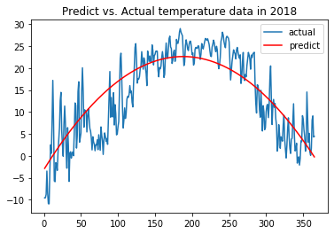

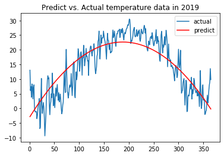

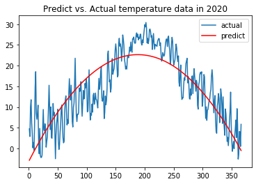

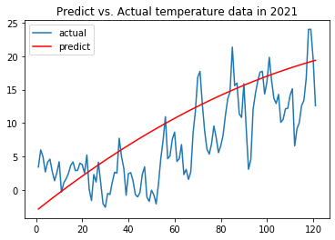

```python
plt.plot(range(1,366), isd_df3['temperature'],label='actual')
xp = np.linspace(1, 365, 365)
plt.title('Predict vs. Actual temperature data in 2018')
plt.plot(xp, z(xp), c='r',label='predict')
plt.legend()
plt.show()

plt.plot(range(1,366),isd_df4['temperature'],label='actual')
xp = np.linspace(1, 365, 365)
plt.title('Predict vs. Actual temperature data in 2019')
plt.plot(xp, z(xp), c='r',label='predict')
plt.legend()
plt.show()


plt.plot(range(1,367),isd_df1['temperature'],label='actual')
xp = np.linspace(1, 366, 366)
plt.title('Predict vs. Actual temperature data in 2020')
plt.plot(xp, z(xp), c='r',label='predict')
plt.legend()
plt.show()


plt.plot(range(1,122),isd_df5['temperature'],label='actual')
xp = np.linspace(1, 121, 121)
plt.title('Predict vs. Actual temperature data in 2021')
plt.plot(xp, z(xp), c='r',label='predict')
plt.legend()
plt.show()
```

To more directly show the difference between the predicted data and the actual data, we decide to calculate the total sum of the square difference using the formula

$r^2 = (actual - predicted)^2$

```python
# The function to find total differences

def find_residual(list1, list2):
    residual = list(map(lambda x, y: (x-y)**2, list1, list2))
    print(sum(residual))
```

```python
y_data = []
xp = np.linspace(1, 365, 365)
for i in isd_df3['temperature']:
    y_data.append(i)
pred_list = z(xp)
print("Residual in year 2018:")
find_residual(y_data,pred_list)
print()

y_data = []
xp = np.linspace(1, 365, 365)
for i in isd_df4['temperature']:
    y_data.append(i)
pred_list = z(xp)
print("Residual in year 2019:")
find_residual(y_data,pred_list)
print()

y_data = []
xp = np.linspace(1, 366, 366)
for i in isd_df1['temperature']:
    y_data.append(i)
pred_list = z(xp)
print("Residual in year 2020:")
find_residual(y_data,pred_list)
print()

y_data = []
xp = np.linspace(1, 121, 121)
for i in isd_df5['temperature']:
    y_data.append(i)
pred_list = z(xp)
print("Residual in year 2021:")
find_residual(y_data,pred_list)
```

```
Residual in year 2018:
10369.3000311625

Residual in year 2019:
8777.352868795171

Residual in year 2020:
8397.156631554335

Residual in year 2021:
3733.3719256281847
```

From the residual, we could know that the residual is quite large for each year. Therefore, we tried to see if we can get a better result using a higher degree model. Hence, we decide to try 4 degrees to see the result

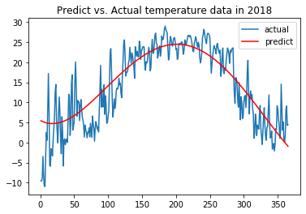

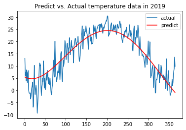

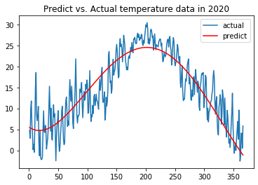

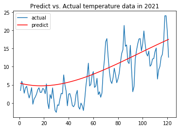

```
Residual in year 2018:
8564.584850610305

Residual in year 2019:
6142.4639594605205

Residual in year 2020:
5750.348797076331

Residual in year 2021:
2305.3107000954096
```

```python
z = np.poly1d(np.polyfit(range(1,366),isd_df2['temperature'], 4))
plt.plot(range(1,366), isd_df3['temperature'],label='actual')
xp = np.linspace(1, 365, 365)
plt.title('Predict vs. Actual temperature data in 2018')
plt.plot(xp, z(xp), c='r',label='predict')
plt.legend()
plt.show()

plt.plot(range(1,366),isd_df4['temperature'],label='actual')
xp = np.linspace(1, 365, 365)
plt.title('Predict vs. Actual temperature data in 2019')
plt.plot(xp, z(xp), c='r',label='predict')
plt.legend()
plt.show()


plt.plot(range(1,367),isd_df1['temperature'],label='actual')
xp = np.linspace(1, 366, 366)
plt.title('Predict vs. Actual temperature data in 2020')
plt.plot(xp, z(xp), c='r',label='predict')
plt.legend()
plt.show()


plt.plot(range(1,122),isd_df5['temperature'],label='actual')
xp = np.linspace(1, 121, 121)
plt.title('Predict vs. Actual temperature data in 2021')
plt.plot(xp, z(xp), c='r',label='predict')
plt.legend()
plt.show()

y_data = []
xp = np.linspace(1, 365, 365)
for i in isd_df3['temperature']:
    y_data.append(i)
pred_list = z(xp)
print("Residual in year 2018:")
find_residual(y_data,pred_list)
print()

y_data = []
xp = np.linspace(1, 365, 365)
for i in isd_df4['temperature']:
    y_data.append(i)
pred_list = z(xp)
print("Residual in year 2019:")
find_residual(y_data,pred_list)
print()

y_data = []
xp = np.linspace(1, 366, 366)
for i in isd_df1['temperature']:
    y_data.append(i)
pred_list = z(xp)
print("Residual in year 2020:")
find_residual(y_data,pred_list)
print()

y_data = []
xp = np.linspace(1, 121, 121)
for i in isd_df5['temperature']:
    y_data.append(i)
pred_list = z(xp)
print("Residual in year 2021:")
find_residual(y_data,pred_list)
```

We could find the residual does decrease. However, no matter which degree, the equation we found will get the exact same prediction for every day in a different year. Even though the general trend of each year is similar, as we found before, but we also found that there might be a significant difference in the daily temperature. For example, in the violin plot we made before, we could see the temperature distribution for the same month is varied over each year. Therefore, even though the equation we found using polynomial regression can represent the overall trend of temperature change, it can not precisely predict the daily temperature.

## Part 4.2 Long short-term memory

To solve the problem we found in 4.1, we need to find a better approach to train our model. We start by using our common sense that the temperature in the current day somewhat depends on the past few days. For instance, if the past few days show a trend of increasing temperature, it is unlikely the next day will drop the temperature significantly. Furthermore, using such a temperature sequence, we could also catch some patterns that might indicate there might be a drop or increase in temperature in the future. Therefore, our model could represent the sudden changes in the daily temperature, which is shown in our plot of daily temperature.

To achieve our goal, we choose to use an RNN (recurrent neural network). In an RNN, its output could be used as part of the next input, so that information can propagate along as the network passes over the sequence. Therefore, we can exhibit temporal dynamic behavior, and we think RNN can recognize temperature's sequential characteristics and use patterns to predict the daily temperature. To avoid the potential problem of vanishing gradient because of the computations involved in the traditional RNN process, we decide to use LSTM (Long short-term memory), which is a special kind of RNN.

We decide to implement and train our LSTM model using PyTorch. For better performance, we first enable the CUDA.

```python
# Check if our system supports CUDA
is_cuda = torch.cuda.is_available()

# If so, enable the cude
if is_cuda:
    device = torch.device("cuda")
    print("GPU is available")
else:
    device = torch.device("cpu")
    print("GPU not available, CPU used")
```

```
GPU is available
```

## Parameters setting

```python
input_size = 4
hidden_size = 8
output_size = 1
num_layers = 2
seq_len = 362
```

## Data normalization

Without data normalization, widely different scales fed to our model will cause the network to weigh the features not equally. This can cause a false prioritization of some features over the others in the representation.

We decide to use linear scaling to normalize our data using the formula below. We choose this method because we could easily find the upper and lower bounds on our data with few or no outliers from the violin plot we made.

$x^{'} = （x - x_{min}）/ (x_{max} - x_{min})$

## Training dataset

We choose to use the temperature data from 2017 as our training set, therefore, we could test the validity of our model using the data from 2018 to 2021.

The training input set will be a list of 4-day temperature sequences (4 is our characteristic dimension as mentioned before), and the target set will be a list of the 5th-day temperature.

```python
# Read data from csv file
isd_df = pd.read_csv('out2017.csv')
data = isd_df['temperature']

# Find xmin and xmax
min_data = np.min(data)
max_data = np.max(data)

# data normalization
scalar = max_data - min_data
data = list(map(lambda x: (x - min_data) / scalar, data))

# Get training dataset
train_x_data = []
train_y_data = []
for i in range(len(data)-input_size):
    train_x_data.append(data[i:i+input_size])
    train_y_data.append(data[i+input_size])
train_x_data = np.asarray(train_x_data)
train_y_data = np.asarray(train_y_data )
train_x_data = train_x_data.reshape(-1, 1, input_size)
train_y_data = train_y_data.reshape(-1, 1, output_size)
train_x_data = torch.from_numpy(train_x_data)
train_y_data = torch.from_numpy(train_y_data)
```

## Create LSTM model

Using the parameter we set before, we use Pytorch to create a LSTM model.

```python
class RNN(torch.nn.Module):
    def __init__(self,input_size,hidden_size,output_size,num_layers):
        super(RNN, self).__init__()
        self.lstm = torch.nn.LSTM(input_size,hidden_size,num_layers)
        self.out = torch.nn.Linear(hidden_size,output_size)
    def forward(self,x):
        x1,_ = self.lstm(x)
        a,b,c = x1.shape
        out = self.out(x1.view(-1,c))
        out1 = out.view(a,b,-1)
        return out1

rnn = RNN(input_size,hidden_size,output_size,num_layers)
```

Define the loss function and optimizer for our model

```python
optimizer = torch.optim.Adam(rnn.parameters(),lr = 1e-1)
criterion = torch.nn.MSELoss()
```

## Training step

To prevent overfitting while trying to get a accurate model, we try 200 step to train our model.

```python
for i in range(200):
    inputs = train_x_data.type(torch.FloatTensor)
    inputs = inputs.cuda()
    labels = train_y_data.type(torch.FloatTensor)
    labels = labels.cuda()
    rnn.cuda()
    out = rnn(inputs)
    loss = criterion(out,labels)
    optimizer.zero_grad()
    loss.backward()
    optimizer.step()
    if (i+1)%10==0:
        print('Step:{}, Loss:{:.5f}'.format(i+1, loss.item()))
```

```
Step:10, Loss:0.07233
Step:20, Loss:0.04591
Step:30, Loss:0.01933
Step:40, Loss:0.01614
Step:50, Loss:0.01483
Step:60, Loss:0.01388
Step:70, Loss:0.01321
Step:80, Loss:0.01236
Step:90, Loss:0.01147
Step:100, Loss:0.01051
Step:110, Loss:0.00948
Step:120, Loss:0.00871
Step:130, Loss:0.00815
Step:140, Loss:0.00764
Step:150, Loss:0.00722
Step:160, Loss:0.00705
Step:170, Loss:0.00696
Step:180, Loss:0.00686
Step:190, Loss:0.01073
Step:200, Loss:0.00704
```

We could see the loss is decrease during the training.

## Testing step

Now, our model is trained, so that we could use our model to predict the temperature of other years to check the validity of our model. We will use a similar method as we did in the training step to get the testing input and actual output. After comparing with the actual output, we can find how well our model could predict the daily temperature using the past four days' temperature.

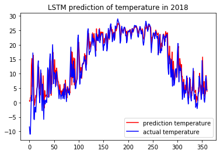

```
Residual for 2018
4357.936532879882
```

```python
# Getting the test data
isd_df = pd.read_csv('out2018.csv')

# Normalize the data
data = isd_df['temperature']
data_nomalized = list(map(lambda x: (x - min_data) / scalar, data))

# Getting the testing input and actual temperature dataset
x_data = []
y_data = []
for i in range(len(data)-input_size):
    x_data.append(data_nomalized[i:i+input_size])
    y_data.append(data[i+input_size])
x_data = np.asarray(x_data)
x_data = x_data.reshape(-1, 1, input_size)
x_data = torch.from_numpy(x_data)
var_x = x_data.type(torch.FloatTensor)
var_x = var_x.cuda()

# Using our model to predict the daily temperature.
pred = rnn(var_x)
pred = pred.cpu()

# Convert the normalized data back to actural temperature data
pred_list = pred.view(-1).data.numpy().tolist()
pred_list = list(map(lambda x: (x*scalar)+min_data, pred_list))

# Create the plot
plt.title("LSTM prediction of temperature in 2018")
plt.plot(pred_list, 'r', label='prediction temperature')
plt.plot(y_data, 'b', label='actual temperature')
plt.legend()
plt.figure(figsize=(10,5))
plt.show()

print("Residual for 2018")
find_residual(pred_list,y_data)
```

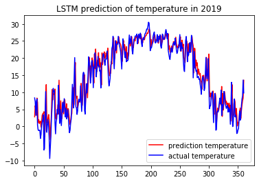

```
Residual for 2019
3360.829513128073
```

```python
# Getting the test data
isd_df = pd.read_csv('out2019.csv')

# Normalize the data
data = isd_df['temperature']
data_nomalized = list(map(lambda x: (x - min_data) / scalar, data))

# Getting the testing input and actual temperature dataset
x_data = []
y_data = []
for i in range(len(data)-input_size):
    x_data.append(data_nomalized[i:i+input_size])
    y_data.append(data[i+input_size])
x_data = np.asarray(x_data)
x_data = x_data.reshape(-1, 1, input_size)
x_data = torch.from_numpy(x_data)
var_x = x_data.type(torch.FloatTensor)
var_x = var_x.cuda()

# Using our model to predict the daily temperature.
pred = rnn(var_x)
pred = pred.cpu()

# Convert the normalized data back to actural temperature data
pred_list = pred.view(-1).data.numpy().tolist()
pred_list = list(map(lambda x: (x*scalar)+min_data, pred_list))

# Create the plot
plt.title("LSTM prediction of temperature in 2019")
plt.plot(pred_list, 'r', label='prediction temperature')
plt.plot(y_data, 'b', label='actual temperature')
plt.legend()
plt.figure(figsize=(10,5))
plt.show()

print("Residual for 2019")
find_residual(pred_list,y_data)
```

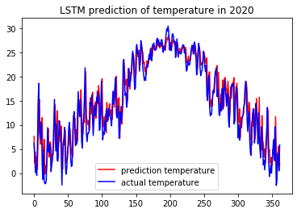

```
Residual for 2020
3453.7242684008875
```

```python
# Getting the test data
isd_df = pd.read_csv('out2020.csv')

# Normalize the data
data = isd_df['temperature']
data_nomalized = list(map(lambda x: (x - min_data) / scalar, data))

# Getting the testing input and actual temperature dataset
x_data = []
y_data = []
for i in range(len(data)-input_size):
    x_data.append(data_nomalized[i:i+input_size])
    y_data.append(data[i+input_size])
x_data = np.asarray(x_data)
x_data = x_data.reshape(-1, 1, input_size)
x_data = torch.from_numpy(x_data)
var_x = x_data.type(torch.FloatTensor)
var_x = var_x.cuda()

# Using our model to predict the daily temperature.
pred = rnn(var_x)
pred = pred.cpu()

# Convert the normalized data back to actural temperature data
pred_list = pred.view(-1).data.numpy().tolist()
pred_list = list(map(lambda x: (x*scalar)+min_data, pred_list))

# Create the plot
plt.title("LSTM prediction of temperature in 2020")
plt.plot(pred_list, 'r', label='prediction temperature')
plt.plot(y_data, 'b', label='actual temperature')
plt.legend()
plt.figure(figsize=(10,5))
plt.show()

print("Residual for 2020")
find_residual(pred_list,y_data)
```

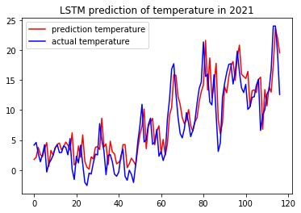

```
Residual for 2021
1153.9092499932406
```

```python
# Getting the test data
isd_df = pd.read_csv('out2021.csv')

# Normalize the data
data = isd_df['temperature']
data_nomalized = list(map(lambda x: (x - min_data) / scalar, data))

# Getting the testing input and actual temperature dataset
x_data = []
y_data = []
for i in range(len(data)-input_size):
    x_data.append(data_nomalized[i:i+input_size])
    y_data.append(data[i+input_size])
x_data = np.asarray(x_data)
x_data = x_data.reshape(-1, 1, input_size)
x_data = torch.from_numpy(x_data)
var_x = x_data.type(torch.FloatTensor)
var_x = var_x.cuda()

# Using our model to predict the daily temperature.
pred = rnn(var_x)
pred = pred.cpu()

# Convert the normalized data back to actural temperature data
pred_list = pred.view(-1).data.numpy().tolist()
pred_list = list(map(lambda x: (x*scalar)+min_data, pred_list))

# Create the plot
plt.title("LSTM prediction of temperature in 2021")
plt.plot(pred_list, 'r', label='prediction temperature')
plt.plot(y_data, 'b', label='actual temperature')
plt.legend()
plt.figure(figsize=(10,5))
plt.show()

print("Residual for 2021")
find_residual(pred_list,y_data)
```

## Part 4.3 Analysis

Comparing to the polynomial regression model, first, even compared with the degree 4 result, we could see a significant improvement in total difference in one year.

Another significant improvement is that our model can represent temporal dynamic behavior. From the plot we generated, we can find that our model can predict the sudden change of the data, besides, the temporal change we captured using our model is almost accurate comparing with the real data.

# Part5 Communication of insights attained

## Part 5.1 Insight attained

From the comparison between using polynomial regression and using machine learning techniques, we find that LSTM can get a much better result than polynomial regression. Besides, through the result of LSTM, we also realize that LSTM can recognize and properly forecast the sudden change of the future daily temperature.

Therefore, we think recurrent neural networks are very helpful to predict the weather.

## Part 5.2 Limitation and future work

In our project, we only use temperature as our input. For better accuracy, we can add other features like wind speed and cloud coverage to better train the model.

Besides, the weather pattern will differ for different locations, therefore we can also add latitude and longitude as features.